# 心理学实验

> 背景信息：在一个斯特鲁普（Stroop）任务中，有一组表示颜色的单词，比如“红色，蓝色...”，对照组的显示颜色和文字含义相同（比如“红色”显示为红色），实验组的不同（比如“红色”显示为绿色）。要求参与者分别在两种情况下，说出每个单词的显示颜色。在每个情况中，我们将计量说出相同数量单词的实际显示颜色的时间。每位参与者必须全部完成并记录每种条件下使用的时间。

## 变量

- 自变量independent variable：测试条件。即“文字”及“显示颜色”相同，或不相同。
- 因变量predict variable：每个条件下，受试者说出同等大小的列表中的墨色名称的时间。

## 零假设

- 零假设H0：μ(congruent-incongruent)≥0，即当“文字”及“显示颜色”不相同时，受试者说出同等大小的列表中的墨色名称的时间会不会增加。
- 对立假设Ha：μ(congruent-incongruent)<0，即当“文字”及“显示颜色”不相同时，受试者说出同等大小的列表中的墨色名称的时间会增加。

## 选择统计检验类型

选择相依样本t检验one-sample t-test，负向单尾检验-direction one tailed test，原因如下：

1. 符合假设检验三原则
   - 随机:因为题干没特殊说明，所以认为是随机样本，可以用来估算总体偏差。
   - 控制：两组实验的条件（自变量）不同。
   - 可重复：在题干没有特殊说明的情况下，认为参与者之间相互独立。
2. 符合t检验三原则
   - 无法确定总体参数（总体偏差）。
   - 样本量小（<30)，t分布给出的置信区间比正态分布的更宽。
   - 总体为正态分布。受试者所用时间（因变量）属于连续变量，且为测量值，可假设为正态分布。
3. 相依样本。同一受试者要参加条件变化前后两次测量，属于相依样本。
4. 单尾检验。已定义的零假设具有方向性，所以选择负向单尾检验。

结论：可以并只能选择相依样本t检验（单尾）。

## 描述统计量

| 组别 | 均值 | 标准差 |
| --- | --- | --- |
| 对照组 | 14.05 | 3.56 |
| 实验组 | 22.02 | 4.80 |
| 差值集 | -7.96 | 4.86 |

## 可视化

观察结果：通过比较发现第二组样本的中位数大于第一组，由于中位数可以更好的代表样本平均水平，故推测样本中的所有受试者，在条件变化后，花费时间“整体水平上”增加了，认为当“文字”及“显示颜色”不相同时，受试者说出同等大小的列表中的墨色名称的时间可能会增加。

```
[(0, 35)]
```

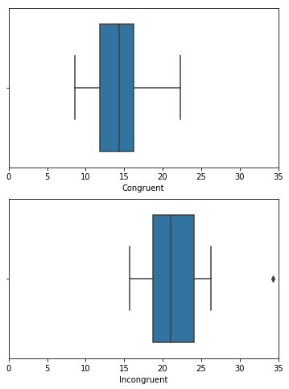

```python
import pandas as pd
import seaborn as sns
import matplotlib.pyplot as plt

stroop_df = pd.read_csv('https://smilespark.github.io/p0/stroopdata.csv',encoding='ANSI')
f, axes = plt.subplots(2, 1, sharey=True, figsize=(6,8))
sns.boxplot(x='Congruent', data=stroop_df, ax=axes[0]).set(xlim=(0,35))
sns.boxplot(x='Incongruent', data=stroop_df, ax=axes[1]).set(xlim=(0,35))
```

## 推论统计量

### 假设检验

- 显著性水平：α=0.05
- 自由度：df=n-1=24-1=23
- t临界值：t-critical=-1.714（查表）
- t统计量：t-statistic=（差值集均值-总体均值）/(总体标准差的估计值/样本量的平方根)=((14.05-22.02)-0)/(4.86/√24)= -8.03
- 结论：t(23)=-8.03, p<.05, -direction

### 均值差异的置信区间confidence interval on the mean difference

- 差值集均值：-7.96
- 误差范围：magin of error=2.069×4.86/√24=2.05
- 置信区间：95%CI=(-10.01, -5.91)

### 效应量

- 差异性度量：Cohen’s d=（差值集均值-假设的总体差值）/差值集标准偏差=-1.64
- 相关性度量：（决定系数）R-Square=t统计量的平方/(t统计量的平方+自由度)=0.74

## 结论

拒绝零假设，差异水平为-1.64，且差异的74%归因于假设条件。

也就是说，当“文字”及“显示颜色”不相同时，受试者说出同等大小的列表中的墨色名称的时间会增加。符合期望。

## 扩展信息

导致所观察到的效应的原因可能是：后摄抑制

（Retroactive interference (RI) is a phenomenon that occurs when newly learned information interferes with and impedes the recall of previously learned information.）